# Canonical Correlation Analysis

Joseph Korszun

## Canonical Correlation Analysis

### What is Canonical Correlation Analysis?

- Canonical Correlate Analysis (CCA) seeks to identify and quantify associations between two sets of variables.
- Developed by Harold Hotelling where he was providing an example of relating arithmetic reading speed and arithmetic reading power
- Focuses on the correlation between the linear combination of variables in one set and the linear combination in another set.

### Defining Canonical Correlations

- Determine the pair of linear combinations having the largest correlation
- Determine the pair of linear combinations having the largest correlation among all pairs uncorrelated with the initially selected pair, and so forth
- The pairs of linear combinations are called canonical variables
- Their correlations are called Canonical Correlations

### When to use CCA?

- Large Sample Size required
- Multivariate Normal Distribution assumptions for both data sets of variables
- Samples can be used from large data sets, but they should be adequate in size

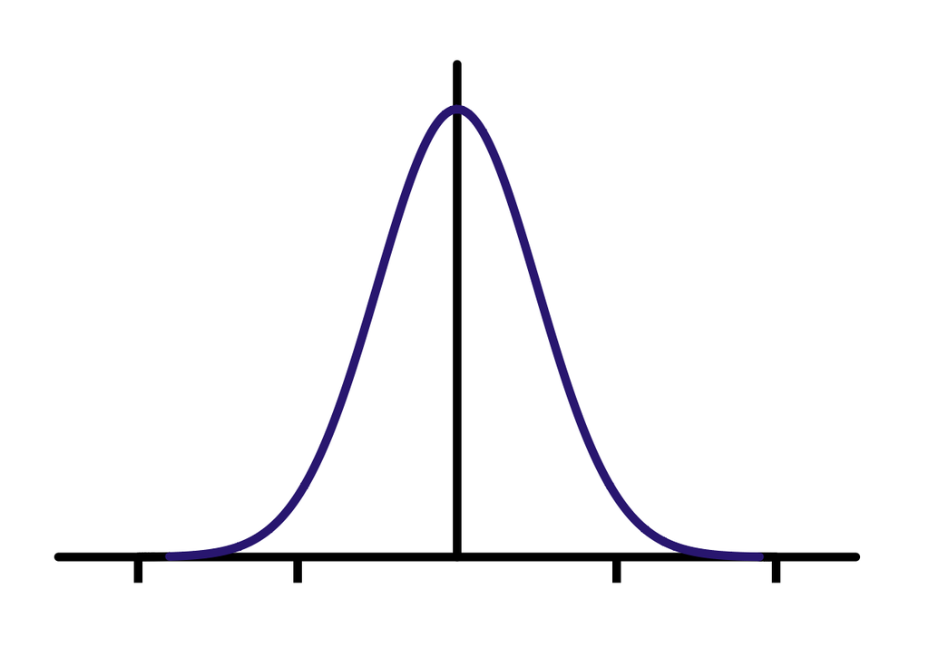

### Canonical Variates and Canonical Correlations

### An Example in R

```r
# load libraries
library(lme4) # linear mixed-effect modeling
library(CCA) # CCA package
```

```r
library(CCP) # significance tests for CCA
library(ggplot2) # plotting package

# read in data
example <- read.csv("CanonicalCorrelationAnalysisData.csv", header = T, sep = ",")

# print 5 rows
head(example)
```

```
##   PsychTest1 PsychTest2 YrsEdu  IQ HrsTrn HrsWrk ClientSat SuperSat ProjCompl
## 1         62         78      5  97      6     33        84       59        34
## 2         46         27      2  93      7     54        55       38        56
## 3         68         75      2  96      5     47        70       68        38
## 4         55         56      4 103      7     80        63       81        78
## 5         51         32      4  98      5     53        55       39        56
## 6         51         66      3 102     10     56        63       68        57
```

```r
# Define X and Y data
X = example[,c('PsychTest1', 'PsychTest2', 'YrsEdu', 'IQ', 'HrsTrn', 'HrsWrk')]
Y = example[,c('ClientSat', 'SuperSat', 'ProjCompl')]

# Fit Canonical Correlation Analysis using built-in cancor function
model <- cancor(X,Y)

# Show the model results
print(model)
```

```
## $cor
## [1] 0.9900690 0.9321929 0.8093344
##
## $xcoef
##                     [,1]          [,2]          [,3]          [,4]
## PsychTest1 -9.923542e-05 -0.0018044569  3.494256e-03 -4.677900e-04
## PsychTest2 -6.736361e-04 -0.0009630136 -2.386238e-03  5.706027e-04
## YrsEdu     -6.669989e-04 -0.0003356070  5.259408e-03  7.573749e-03
## IQ         -6.778766e-04 -0.0008191085 -2.126358e-03 -9.293717e-03
## HrsTrn     -7.909143e-05 -0.0019560206  2.452931e-03 -1.837929e-04
## HrsWrk     -1.252183e-03  0.0005194347 -5.484026e-05  9.797022e-05
##                     [,5]          [,6]
## PsychTest1  0.0004629180  0.0009468091
## PsychTest2 -0.0002165319 -0.0003051851
## YrsEdu     -0.0152364295 -0.0108830216
## IQ          0.0003930777  0.0006152953
## HrsTrn      0.0125216480 -0.0179054197
## HrsWrk     -0.0010276758  0.0015111622
##
## $ycoef
##                    [,1]         [,2]         [,3]
## ClientSat -5.335248e-05 -0.001031411  0.001769951
## SuperSat  -1.126052e-03 -0.001572913 -0.003065230
## ProjCompl -6.594502e-04  0.001690408  0.002148974
##
## $xcenter
## PsychTest1 PsychTest2     YrsEdu         IQ     HrsTrn     HrsWrk
##     49.990     49.286      2.506     97.587      6.028     47.810
##
## $ycenter
## ClientSat  SuperSat ProjCompl
##    54.970    49.912    48.127
```

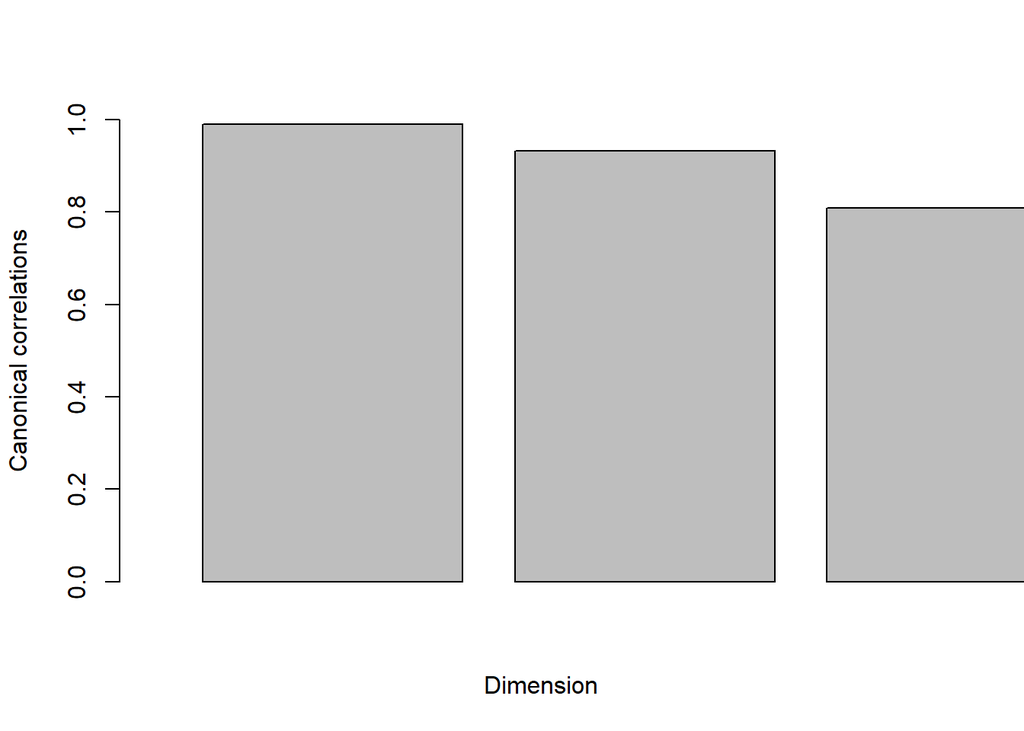

```r
# Show the Canonical correlations per dimension to decide on the number of dimensions
barplot(model$cor, xlab = "Dimension", ylab = "Canonical correlations", ylim = c(0,1), xlim=c(0,3))
```

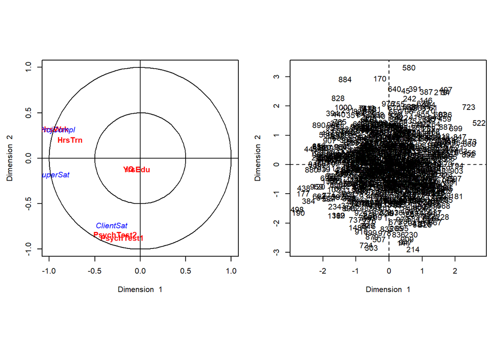

```r
# refit model using canonical correlation function
model2 <- cc(X, Y)

# plot model on scatter plot (Dimensions 1 and 2)
plt.cc(model2, var.label = TRUE)
```

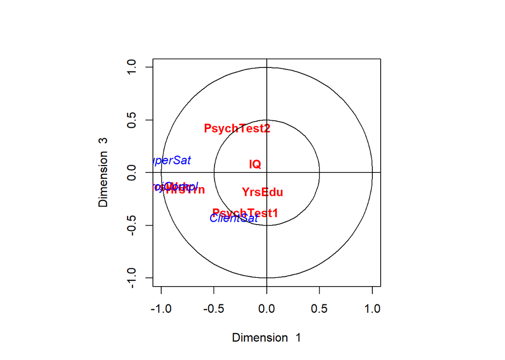

```r
# plot model on scatter plot (Dimensions 1 and 3)
plt.var(model2, 1, 3, var.label = TRUE)
```

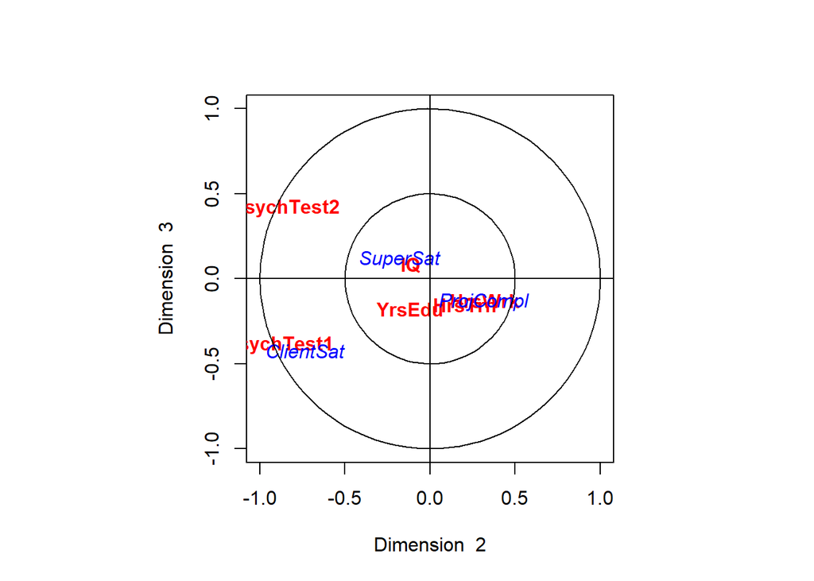

```r
# plot model on scatter plot (Dimensions 2 and 3)
plt.var(model2, 2, 3, var.label = TRUE)
```

### An Example in Python

```python
# import libraries
import pandas as pd


# import the csv file directly from an s3 bucket
example = pd.read_csv('CanonicalCorrelationAnalysisData.csv')


from sklearn.cross_decomposition import CCA

# Split the data in X and Y
X = example[['PsychTest1',  'PsychTest2', 'YrsEdu', 'IQ', 'HrsTrn', 'HrsWrk']]
Y = example[['ClientSat',   'SuperSat', 'ProjCompl']]

# Instantiate the Canonical Correlation Analysis with 2 components
my_cca = CCA(n_components=2)

# Fit the model
my_cca.fit(X, Y)


# Obtain the rotation matrices
xrot = my_cca.x_rotations_
yrot = my_cca.y_rotations_

# Put them together in a numpy matrix
xyrot = np.vstack((xrot,yrot))

nvariables = xyrot.shape[0]

plt.figure(figsize=(15, 15))
plt.xlim((-1,1))
plt.ylim((-1,1))

# Plot an arrow and a text label for each variable
for var_i in range(nvariables):
  x = xyrot[var_i,0]
  y = xyrot[var_i,1]

  plt.arrow(0,0,x,y)
  plt.text(x,y,data.columns[i], color='red' if i >= 6 else 'blue')

# show plot
plt.show()
```

[output not shown]

### References

- Applied Multivariate Statistical Analysis
- [PSU Lecture Material](https://online.stat.psu.edu/stat505/book/export/html/682)
- [UCLA Lecture Material](https://stats.oarc.ucla.edu/r/dae/canonical-correlation-analysis/#:~:text=Canonical%20correlation%20analysis%20is%20used,are%20multiple%20intercorrelated%20outcome%20variables)
- [Towards Data Science Article](https://towardsdatascience.com/canonical-correlation-analysis-b1a38847219d)
- [Medium Article](https://medium.com/analytics-vidhya/canonical-correlation-analysis-cca-in-r-a-non-technical-primer-b67d9bdeb9dd)
- [AWS Dataset](https://articledatas3.s3.eu-central-1.amazonaws.com/CanonicalCorrelationAnalysisData.csv)